# Railways Desert Indicator

## Data cleaning and Integration

1)Kaggle A - Railways data->schedules.json,train.json,stations.json

2)Kaggle B - Census 2011 ->District-level socio-economic data

3)Datameet - Geocodes for mapping stations to districts

```python
import pandas as pd
import numpy as np
import seaborn as sns
import statsmodels.api as sm
import statsmodels.formula.api as smf
import matplotlib.pyplot as plt
from scipy.stats import chi2, norm
from statsmodels.stats.outliers_influence import OLSInfluence
from statsmodels.genmod.generalized_estimating_equations import GEE
from statsmodels.genmod import families
from pathlib import Path
```

### Exploratory Data Analysis

```python
#Load the integrated and cleaned up dataset(Railways + District level codes+ Geocodes)
import geopandas as gpd
rail = gpd.read_file("stations_with_district.gpkg")
rail.shape
```

```
(8240, 19)
```

```python
#Drop missing rows
rail = rail.dropna()
```

```python
rail.head()
```

|  | station_code | lat | lon | unique_trains | terminal_count | avg_distance | avg_duration | frequency | District code | State name | District name | Population | worker_share | agri_share | urban_rate | hr_index | SVI_norm | key | geometry |
| --- | --- | --- | --- | --- | --- | --- | --- | --- | --- | --- | --- | --- | --- | --- | --- | --- | --- | --- | --- |
| 0 | CAPE | 8.088028 | 77.542504 | 22 | 22 | 1605.000000 | 30.227273 | 22 | 629.0 | TAMIL NADU | Kanniyakumari | 1870374.0 | 0.36336 | 0.107217 | 0.825676 | 3.563971 | 0.255957 | 629.0 | MULTIPOLYGON (((77.5911 8.1418, 77.58991 8.145... |
| 1 | SUCH | 8.149479 | 77.466792 | 22 | 0 | 1605.000000 | 30.227273 | 22 | 629.0 | TAMIL NADU | Kanniyakumari | 1870374.0 | 0.36336 | 0.107217 | 0.825676 | 3.563971 | 0.255957 | 629.0 | MULTIPOLYGON (((77.5911 8.1418, 77.58991 8.145... |
| 2 | NCJ | 8.173850 | 77.443470 | 65 | 38 | 1229.969231 | 23.430769 | 65 | 629.0 | TAMIL NADU | Kanniyakumari | 1870374.0 | 0.36336 | 0.107217 | 0.825676 | 3.563971 | 0.255957 | 629.0 | MULTIPOLYGON (((77.5911 8.1418, 77.58991 8.145... |
| 3 | VRLR | 8.194645 | 77.368699 | 36 | 0 | 1447.805556 | 28.000000 | 36 | 629.0 | TAMIL NADU | Kanniyakumari | 1870374.0 | 0.36336 | 0.107217 | 0.825676 | 3.563971 | 0.255957 | 629.0 | MULTIPOLYGON (((77.5911 8.1418, 77.58991 8.145... |
| 4 | NJT | 8.199572 | 77.419432 | 36 | 0 | 1447.805556 | 28.000000 | 36 | 629.0 | TAMIL NADU | Kanniyakumari | 1870374.0 | 0.36336 | 0.107217 | 0.825676 | 3.563971 | 0.255957 | 629.0 | MULTIPOLYGON (((77.5911 8.1418, 77.58991 8.145... |

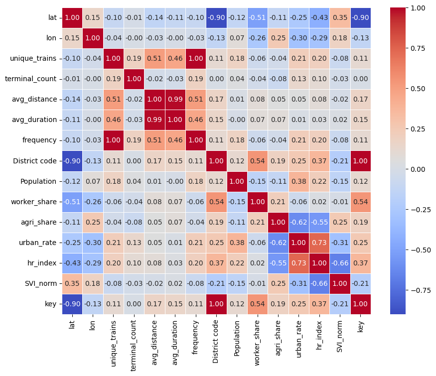

```python
#Correlation Plot for numerical data
numeric_df = rail.select_dtypes(include='number')
correlation_matrix = numeric_df.corr()
plt.figure(figsize=(10, 8))
sns.heatmap(correlation_matrix, annot=True, cmap='coolwarm', fmt=".2f", linewidths=0.5)
plt.show()
```

##### Feature engineering

1.create stations(no.of stations in the corresponding district)

2.create frequency denoter to check if frequency > unique trains to capture high service hubs(remove frequency variable)

3.create interaction term efficiency index (1/avg_duration)(1/avgdistance) to reduce multi-collinearity.

4.offset=np.log(rail["Population"] + 1)

```python
# add number of stations in the district
rail["stations"] = rail.groupby("District code")["station_code"].transform("count")

#high frequency indicator
rail["high_service_indicator"] = (rail["frequency"] > rail["unique_trains"]).astype(int)

#Efficiency Index
rail["efficiency_index"] = np.log(
    (1 / (rail["avg_duration"] + 1e-6)) *
    (1 / (rail["avg_distance"] + 1e-6)))

#define offset
rail["offset"] = np.log(rail["Population"] + 1)
```

```python
rail = rail.drop(columns=["frequency", "avg_distance", "avg_duration"])
rail.head()
```

|  | station_code | lat | lon | unique_trains | terminal_count | District code | State name | District name | Population | worker_share | agri_share | urban_rate | hr_index | SVI_norm | key | geometry | stations | high_service_indicator | efficiency_index | offset |
| --- | --- | --- | --- | --- | --- | --- | --- | --- | --- | --- | --- | --- | --- | --- | --- | --- | --- | --- | --- | --- |
| 0 | CAPE | 8.088028 | 77.542504 | 22 | 22 | 629.0 | TAMIL NADU | Kanniyakumari | 1870374.0 | 0.36336 | 0.107217 | 0.825676 | 3.563971 | 0.255957 | 629.0 | MULTIPOLYGON (((77.5911 8.1418, 77.58991 8.145... | 11 | 0 | -10.789624 | 14.44165 |
| 1 | SUCH | 8.149479 | 77.466792 | 22 | 0 | 629.0 | TAMIL NADU | Kanniyakumari | 1870374.0 | 0.36336 | 0.107217 | 0.825676 | 3.563971 | 0.255957 | 629.0 | MULTIPOLYGON (((77.5911 8.1418, 77.58991 8.145... | 11 | 0 | -10.789624 | 14.44165 |
| 2 | NCJ | 8.173850 | 77.443470 | 65 | 38 | 629.0 | TAMIL NADU | Kanniyakumari | 1870374.0 | 0.36336 | 0.107217 | 0.825676 | 3.563971 | 0.255957 | 629.0 | MULTIPOLYGON (((77.5911 8.1418, 77.58991 8.145... | 11 | 0 | -10.268795 | 14.44165 |
| 3 | VRLR | 8.194645 | 77.368699 | 36 | 0 | 629.0 | TAMIL NADU | Kanniyakumari | 1870374.0 | 0.36336 | 0.107217 | 0.825676 | 3.563971 | 0.255957 | 629.0 | MULTIPOLYGON (((77.5911 8.1418, 77.58991 8.145... | 11 | 0 | -10.610009 | 14.44165 |
| 4 | NJT | 8.199572 | 77.419432 | 36 | 0 | 629.0 | TAMIL NADU | Kanniyakumari | 1870374.0 | 0.36336 | 0.107217 | 0.825676 | 3.563971 | 0.255957 | 629.0 | MULTIPOLYGON (((77.5911 8.1418, 77.58991 8.145... | 11 | 0 | -10.610009 | 14.44165 |

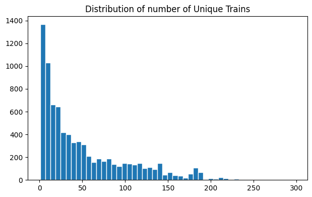

```python
# Distribution of Unique trains,the response variable
plt.figure(figsize=(12, 4))

plt.subplot(1, 2, 1)
plt.hist(rail["unique_trains"], bins=50, edgecolor="white")
plt.title("Distribution of number of Unique Trains")
plt.tight_layout()
plt.show()
```

Since this is a count, we plan to do Poisson Regression with population as the offset. But,let's check for over-dispersion first.

```python
#compute  error and variance
mu = rail['unique_trains'].mean()
var = rail['unique_trains'].var()
print(mu,var)
```

```
50.167597765363126 2614.8311326471276
```

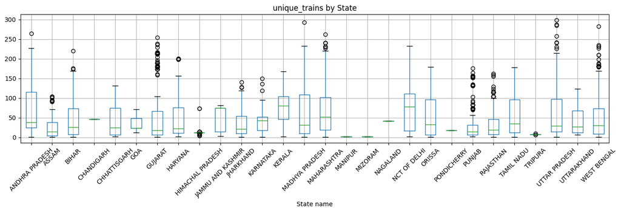

```python
#Distribution of the response variable across states
plt.figure(figsize=(14, 5))
rail.boxplot(column='unique_trains', by='State name', figsize=(14,5),
           rot=45)
plt.title('unique_trains by State')
plt.suptitle('')
plt.tight_layout()
plt.show()
```

We see that there are many outliers.

### Outlier screening and handling

```python
#For poisson, we check for outliers with residuals, let's build a baseline model with poisson first to check
#if there really is overdispersion via residual check.
# base model with only the railway network predictors,clustered by district to tackle the stderror
import statsmodels.api as sm

X = rail[["terminal_count", "efficiency_index", "high_service_indicator", "stations"]]
X = sm.add_constant(X)

y = rail["unique_trains"]
offset = np.log(rail["Population"] + 1)

base_model = sm.GLM(
    y, X,
    family=sm.families.Poisson(),
    offset=offset
).fit(
    cov_type="cluster",
    cov_kwds={"groups": rail["District code"]}
)
print(base_model.summary())
```

```
                 Generalized Linear Model Regression Results
==============================================================================
Dep. Variable:          unique_trains   No. Observations:                 8234
Model:                            GLM   Df Residuals:                     8229
Model Family:                 Poisson   Df Model:                            4
Link Function:                    Log   Scale:                          1.0000
Method:                          IRLS   Log-Likelihood:            -1.5919e+05
Date:                Mon, 27 Apr 2026   Deviance:                   2.7619e+05
Time:                        08:07:23   Pearson chi2:                 7.09e+06
No. Iterations:                     6   Pseudo R-squ. (CS):              1.000
Covariance Type:              cluster
==========================================================================================
                             coef    std err          z      P>|z|      [0.025      0.975]
------------------------------------------------------------------------------------------
const                    -14.5017      0.448    -32.393      0.000     -15.379     -13.624
terminal_count             0.0096      0.001      6.922      0.000       0.007       0.012
efficiency_index          -0.4144      0.044     -9.369      0.000      -0.501      -0.328
high_service_indicator     0.1405      0.068      2.057      0.040       0.007       0.274
stations                  -0.0231      0.003     -7.979      0.000      -0.029      -0.017
==========================================================================================
```

```python
#Do we have overdispersion?
deviance = base_model.deviance
df_resid = base_model.df_resid

phi_hat = deviance / df_resid
print("Dispersion:", phi_hat)
```

```
Dispersion: 33.56270793651445
```

Over-dispersion exists as shown by the EDA.This model is not considered good.Therefore,we need to go with either quassi-poisson or negative binomial regression. Since the difference is too high, we opt for negative binomial regression.

```python
#Investigate outliers by residual thresholds because Cook's distance doesn't hold well for GLM
#deviance residuals
dev_resid = base_model.resid_deviance
pearson_resid = base_model.resid_pearson
```

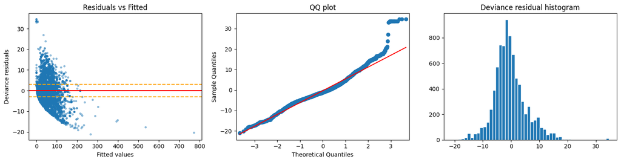

```python
#residual analysis
fig, axes = plt.subplots(1, 3, figsize=(15, 4))

axes[0].scatter(base_model.fittedvalues, dev_resid, alpha=0.4, s=8)
axes[0].axhline(0, color='r'); axes[0].axhline(3, color='orange', ls='--')
axes[0].axhline(-3, color='orange', ls='--')
axes[0].set_xlabel('Fitted values'); axes[0].set_ylabel('Deviance residuals')
axes[0].set_title('Residuals vs Fitted')

sm.qqplot(dev_resid, line='s', ax=axes[1]); axes[1].set_title('QQ plot')

axes[2].hist(dev_resid, bins=50, edgecolor='white')
axes[2].set_title('Deviance residual histogram')
plt.tight_layout(); plt.show()
```

A series of outliers are in the scatterplots, making it hard to evaluate goodness of fit of the model.

```python
## Assuming GOF: Deviance ~ N(0,1)
##  Evaluate Deviance residuals with threshold 5
outliers = dev_resid[abs(dev_resid) > norm.ppf(.99995)]
print(len(outliers))
```

```
3568
```

```python
## Assuming GOF: Deviance ~ N(0,1)
##  Evaluate Deviance residuals with threshold 10
threshold =10
outliers_mask = np.abs(dev_resid) > threshold
print(f"Potential outliers: {outliers_mask.sum()} / {len(rail)}")
rail['is_outlier'] = outliers_mask
```

```
Potential outliers: 718 / 8234
```

```python
outlier_df = rail[outliers_mask][['station_code', 'State name','District name',
                                'unique_trains', 'terminal_count']]
print(outlier_df.sort_values('unique_trains', ascending=False).head(20))
```

```
     station_code      State name        District name  unique_trains  \
6288          CNB   UTTAR PRADESH         Kanpur Nagar            298
3519           ET  MADHYA PRADESH          Hoshangabad            293
7473          GZB   UTTAR PRADESH            Ghaziabad            287
7493          SBB   UTTAR PRADESH  Gautam Buddha Nagar            285
3491          HWH     WEST BENGAL                Haora            283
1378          BZA  ANDHRA PRADESH              Krishna            264
5224          MGS   UTTAR PRADESH            Chandauli            258
3265          BRC         GUJARAT             Vadodara            254
3984          BWN     WEST BENGAL           Barddhaman            235
7469         NDLS    NCT OF DELHI              Central            233
4024          TIT     WEST BENGAL           Barddhaman            232
4047          KAN     WEST BENGAL           Barddhaman            232
7051          MTJ   UTTAR PRADESH              Mathura            230
2631          BSL     MAHARASHTRA              Jalgaon            230
```

[output cut: 28 more lines]

We see that there are 718 outliers. Even in theory, metros and hubs will be extreme outliers. But we retain them because the model has to learn the behaviours,and these offset any deficiency in surrounding stations.Outliers are not noise—they are the system architecture

```python
rail_df=rail
```

```python
import numpy as np
from scipy.stats import zscore

# Z-score for uniqueness signal
z = zscore(rail_df["unique_trains"])
z_flag = np.abs(z) > 3

# IQR rule
Q1 = rail_df["unique_trains"].quantile(0.25)
Q3 = rail_df["unique_trains"].quantile(0.75)
IQR = Q3 - Q1

iqr_flag = (
    (rail_df["unique_trains"] < Q1 - 1.5 * IQR) |
    (rail_df["unique_trains"] > Q3 + 1.5 * IQR)
)

# Quantile extremes (top/bottom 1%)
upper = rail_df["unique_trains"].quantile(0.99)
lower = rail_df["unique_trains"].quantile(0.01)
quantile_flag = (
    (rail_df["unique_trains"] > upper) |
    (rail_df["unique_trains"] < lower)
)

# Final classification
rail_df["outlier_class"] = 1  # normal

rail_df.loc[iqr_flag | z_flag, "outlier_class"] = 2
rail_df.loc[quantile_flag, "outlier_class"] = 3
```

```python
rail_df["outlier_class"].value_counts()
```

```
outlier_class
1    7905
2     250
3      79
Name: count, dtype: int64
```

### Variable Selection

```python
##VIF check for multicollinearity
from statsmodels.stats.outliers_influence import variance_inflation_factor
pred_cols = ['terminal_count', 'efficiency_index',
             'worker_share', 'urban_rate', 'agri_share','stations',
              'hr_index', 'SVI_norm']
X_vif = sm.add_constant(rail[pred_cols].dropna())
vif_df = pd.DataFrame({
    'feature': X_vif.columns,
    'VIF': [variance_inflation_factor(X_vif.values, i)
            for i in range(X_vif.shape[1])]
})
print(vif_df.sort_values('VIF', ascending=False))
```

```
            feature        VIF
0             const  87.063184
7          hr_index   4.509721
4        urban_rate   3.280404
8          SVI_norm   2.199603
5        agri_share   1.837720
6          stations   1.217682
3      worker_share   1.087331
1    terminal_count   1.020683
2  efficiency_index   1.010762
```

All the predictor variables have <5 VIF,implying we have successfully solved for multi-collinearity by performing PCA for SVI(Social vulnerability Index),human resources index(hr_index),and including the efficieny_index as the interaction variable)

```python
#Forward Step-wise(based on AIC) for Negative binomial
import statsmodels.formula.api as smf
from statsmodels.genmod import families
import warnings
warnings.filterwarnings("ignore")

def stepwise_nb(df, response, candidates, forced, offset_col):
    """
    Greedy forward AIC-based stepwise for Negative Binomial GLM
    """
    current = forced.copy()
    remaining = [c for c in candidates if c not in forced]

    def fit_aic(vars_in):
        formula = f"{response} ~ {' + '.join(vars_in)} + C(Q('State name'))"
        model = smf.glm(
            formula=formula,
            data=df,
            family=families.NegativeBinomial(),
            offset=df[offset_col]
        ).fit()
        return model.aic, model

    best_aic, best_model = fit_aic(current)

    improved = True
    while improved and remaining:
        improved = False
        results = []

        for var in remaining:
            aic, _ = fit_aic(current + [var])
            results.append((aic, var))

        results.sort()
        best_candidate_aic, best_var = results[0]

        if best_candidate_aic < best_aic:
            best_aic = best_candidate_aic
            current.append(best_var)
            remaining.remove(best_var)
            improved = True
            print(f"Added: {best_var} | AIC={best_aic:.2f}")

    _, best_model = fit_aic(current)
    return current, best_model
```

```python
forced_vars = ['terminal_count']
search_vars = ['efficiency_index','worker_share','urban_rate','agri_share','stations','hr_index','SVI_norm','high_service_indicator']
selected_vars, nb_model = stepwise_nb(
    rail_df.dropna(subset=search_vars + forced_vars + ["State name", "offset"]),
    response='unique_trains',
    candidates=search_vars,
    forced=forced_vars,
    offset_col='offset'
)

print("Selected:", selected_vars)
```

```
Added: stations | AIC=80927.84
Added: hr_index | AIC=80844.76
Added: efficiency_index | AIC=79487.35
Added: high_service_indicator | AIC=79481.75
Selected: ['terminal_count', 'stations', 'hr_index', 'efficiency_index', 'high_service_indicator']
```

The AIC-based forward stepwise selection using a Negative Binomial model identifies a well-structured set of predictors explaining variation in unique_trains. The final model retains: terminal_count (baseline structural control) stations hr_index efficiency_index high_service_indicator Railway service allocation is explained by infrastructure + development, not demand or vulnerability.

### Model Fitting

For our analysis, we take the AIC-based forward stepwise regression selected variables as the baseline.

##### Model1(Rail+Development): structural inequality in infrastructure

log(λi)=β0+β1Terminali+β2Efficiencyi+β3stationsi+β4high_service_indicatori+β5HRIndexi+β6Statenamei+log(Pop)

##### Model2(Rail + Development+ Demand): efficiency vs usage mismatch

log(λi)=β0+β1Terminali+β2Efficiencyi+β3stationsi+β4high_service_indicatori+β5WorkerSharei+β6UrbanRatei+β7AgriSharei+β8HRIndexi+β9Statenamei+log(Pop)

##### Model3(Rail + Development+ Demand + Need): equity-adjusted accessibility

log(λi)=β0+β1Terminali+β2Efficiencyi+β3stationsi+β4high_service_indicatori+β5WorkerSharei+β6UrbanRatei+β7AgriSharei+β8HRIndexi+β9SVIi++β10Statenamei+log(Pop)

##### Rail

```
-Terminal
-Efficiency Index
-Stations
-High_service Indicator
```

##### Demand

```
-Worker
-Urban Rate
-Agri Share
```

Share census['worker_share'] = census['Workers'] / census['Population'] census['agri_share'] = census['Agricultural_Workers'] / census['Workers'] census['urban_rate'] = census['Urban_Households'] / census['Households']

##### Development

```
-hr_index(PCA on these terms was performed)

(census['literacy_rate'] = census['Literate'] / census['Population']
census['secondary_share'] = census['Secondary_Education'] / census['Population']
census['graduate_share'] = census['Graduate_Education'] / census['Population'])
```

##### Need(Social Vulnerability Index)

```
-SVI (PCA on these terms was performed)

(census['elderly_share'] = census['Age_Group_50'] / census['Population']
census['female_illiteracy'] = (census['Female'] - census['Female_Literate']) / census['Female'],
census['sc_share'] = census['SC'] / census['Population']
census['st_share'] = census['ST'] / census['Population'])
```

```python
models_spec = {
    'M1': 'unique_trains ~ terminal_count + stations + efficiency_index + high_service_indicator + hr_index + C(Q("State name"))',

    'M2': 'unique_trains ~ terminal_count + stations + efficiency_index + high_service_indicator + hr_index + worker_share + urban_rate + agri_share + C(Q("State name"))',

    'M3': 'unique_trains ~ terminal_count + stations + efficiency_index + high_service_indicator + hr_index + worker_share + urban_rate + agri_share + SVI_norm + C(Q("State name"))'
}
fit_df = rail_df.dropna(
    subset=search_vars + forced_vars + ["offset", "District code", "State name"]
)

criteria = {}

for name, formula in models_spec.items():
    m = smf.glm(
        formula,
        data=fit_df,
        family=families.NegativeBinomial(),
        offset=fit_df["offset"]
    ).fit(
        cov_type="cluster",
        cov_kwds={"groups": fit_df["District code"]}
    )

    criteria[name] = {
        "AIC": m.aic,
        "BIC": m.bic,
        "df_resid": m.df_resid
    }

print(pd.DataFrame(criteria).T)
```

```
             AIC           BIC  df_resid
M1  79481.751084 -65539.658624    8201.0
M2  80911.974440 -64088.387186    8198.0
M3  80835.000155 -64158.345443    8197.0
```

Clearly, Model 1 is the best model out of three,meaning the SVI index ,and the demand variables may cause overfitting. Our hypothesis that social vulnerability index,and demand(worker share,urbanization,agricultural share) may have an influence on the accessibility has to be tested through cross-validation.

##### Model1(Rail+Development): structural inequality in infrastructure(Baseline model)

log(λi)=β0+β1Terminali+β2Efficiencyi+β3stationsi+β4high_service_indicatori+β5HRIndexi+β6Statenamei+log(Pop)

```python
model1 = smf.glm(
        models_spec['M1'],
        data=fit_df,
        family=families.NegativeBinomial(),
        offset=fit_df["offset"]
    ).fit(
        cov_type="cluster",
        cov_kwds={"groups": fit_df["District code"]}
    )
model1.summary()
```

Generalized Linear Model Regression Results

| Dep. Variable: | unique_trains | No. Observations: | 8234 |
| --- | --- | --- | --- |
| Model: | GLM | Df Residuals: | 8201 |
| Model Family: | NegativeBinomial | Df Model: | 32 |
| Link Function: | Log | Scale: | 1.0000 |
| Method: | IRLS | Log-Likelihood: | -39708. |
| Date: | Mon, 27 Apr 2026 | Deviance: | 8400.8 |
| Time: | 08:07:34 | Pearson chi2: | 9.34e+03 |
| No. Iterations: | 100 | Pseudo R-squ. (CS): | 0.3313 |
| Covariance Type: | cluster |  |  |

|  | coef | std err | z | P>\|z\| | [0.025 | 0.975] |
| --- | --- | --- | --- | --- | --- | --- |
| Intercept | -11.4640 | 0.274 | -41.890 | 0.000 | -12.000 | -10.928 |
| C(Q("State name"))[T.ASSAM] | -0.1055 | 0.236 | -0.446 | 0.656 | -0.569 | 0.358 |
| C(Q("State name"))[T.BIHAR] | -0.0072 | 0.185 | -0.039 | 0.969 | -0.369 | 0.355 |
| C(Q("State name"))[T.CHANDIGARH] | -0.4580 | 0.204 | -2.243 | 0.025 | -0.858 | -0.058 |
| C(Q("State name"))[T.CHHATTISGARH] | -0.2509 | 0.189 | -1.325 | 0.185 | -0.622 | 0.120 |
| C(Q("State name"))[T.GOA] | 0.1923 | 0.165 | 1.162 | 0.245 | -0.132 | 0.517 |
| C(Q("State name"))[T.GUJARAT] | -0.2505 | 0.180 | -1.393 | 0.164 | -0.603 | 0.102 |
| C(Q("State name"))[T.HARYANA] | 0.0880 | 0.197 | 0.447 | 0.655 | -0.297 | 0.473 |
| C(Q("State name"))[T.HIMACHAL PRADESH] | -0.5122 | 0.207 | -2.477 | 0.013 | -0.917 | -0.107 |
| C(Q("State name"))[T.JAMMU AND KASHMIR] | 0.7902 | 0.398 | 1.983 | 0.047 | 0.009 | 1.571 |
| C(Q("State name"))[T.JHARKHAND] | 0.3798 | 0.195 | 1.944 | 0.052 | -0.003 | 0.763 |
| C(Q("State name"))[T.KARNATAKA] | -0.4393 | 0.165 | -2.655 | 0.008 | -0.764 | -0.115 |
| C(Q("State name"))[T.KERALA] | -0.5086 | 0.203 | -2.502 | 0.012 | -0.907 | -0.110 |
| C(Q("State name"))[T.MADHYA PRADESH] | 0.5485 | 0.178 | 3.081 | 0.002 | 0.200 | 0.897 |
| C(Q("State name"))[T.MAHARASHTRA] | -0.3322 | 0.155 | -2.145 | 0.032 | -0.636 | -0.029 |
| C(Q("State name"))[T.MANIPUR] | -2.1694 | 0.236 | -9.178 | 0.000 | -2.633 | -1.706 |
| C(Q("State name"))[T.MIZORAM] | -0.0002 | 0.184 | -0.001 | 0.999 | -0.360 | 0.359 |
| C(Q("State name"))[T.NAGALAND] | 0.9573 | 0.158 | 6.056 | 0.000 | 0.647 | 1.267 |
| C(Q("State name"))[T.NCT OF DELHI] | 0.5848 | 0.665 | 0.880 | 0.379 | -0.718 | 1.888 |
| C(Q("State name"))[T.ORISSA] | 0.0578 | 0.176 | 0.328 | 0.743 | -0.287 | 0.403 |
| C(Q("State name"))[T.PONDICHERRY] | -1.0904 | 0.204 | -5.341 | 0.000 | -1.491 | -0.690 |
| C(Q("State name"))[T.PUNJAB] | -0.3359 | 0.184 | -1.825 | 0.068 | -0.697 | 0.025 |
| C(Q("State name"))[T.RAJASTHAN] | -0.2489 | 0.175 | -1.423 | 0.155 | -0.592 | 0.094 |
| C(Q("State name"))[T.TAMIL NADU] | 0.3016 | 0.237 | 1.275 | 0.202 | -0.162 | 0.765 |
| C(Q("State name"))[T.TRIPURA] | -0.6631 | 0.383 | -1.731 | 0.083 | -1.414 | 0.088 |
| C(Q("State name"))[T.UTTAR PRADESH] | -0.0213 | 0.142 | -0.150 | 0.881 | -0.300 | 0.258 |
| C(Q("State name"))[T.UTTARAKHAND] | -0.1600 | 0.401 | -0.399 | 0.690 | -0.946 | 0.626 |
| C(Q("State name"))[T.WEST BENGAL] | -0.2280 | 0.188 | -1.212 | 0.225 | -0.597 | 0.141 |
| terminal_count | 0.0145 | 0.002 | 6.435 | 0.000 | 0.010 | 0.019 |
| stations | -0.0223 | 0.003 | -6.991 | 0.000 | -0.029 | -0.016 |
| efficiency_index | -0.1146 | 0.021 | -5.395 | 0.000 | -0.156 | -0.073 |
| high_service_indicator | 0.2041 | 0.088 | 2.324 | 0.020 | 0.032 | 0.376 |
| hr_index | 0.1770 | 0.036 | 4.887 | 0.000 | 0.106 | 0.248 |

### GOF and Diagnostics

```python
#Do we have overdispersion?
deviance = model1.deviance
df_resid = model1.df_resid

phi_hat = deviance / df_resid
print("Dispersion:", phi_hat)
```

```
Dispersion: 1.0243605002562386
```

```python
#Over-dispersion test
model2 = smf.glm(
    models_spec['M1'],
    data=fit_df,
    family=families.Poisson(),
    offset=fit_df["offset"]
).fit(
    cov_type="cluster",
    cov_kwds={"groups": fit_df["District code"]}
)


#model2.summary()
```

```python
#Do we have overdispersion in Poisson?

deviance = model2.deviance
df_resid = model2.df_resid

phi_hat = deviance / df_resid
print("Dispersion:", phi_hat)
```

```
Dispersion: 30.861549044476547
```

Dispersion is closer to 1 in negative binomial, which means that the negative binomial has successfully absorbed the dispersion.In Poisson, the dispersion is very high,at 30.8 for the same data.

```python
#check overall regression
#method1
#Deviance test
from scipy.stats import chi2

g_stat = model1.null_deviance - model1.deviance
p_value = 1 - chi2.cdf(g_stat, len(model1.params) - 1)

print(g_stat, p_value)
```

```
3313.0284722686756 0.0
```

```python
#method 2
#Likelihood ratio
ll_full = model1.llf
ll_null = model1.llnull

LR_stat = -2 * (ll_null - ll_full)
df = model1.df_model

p_value = 1 - chi2.cdf(LR_stat, df)

print(LR_stat, p_value)
```

```
3313.028472268663 0.0
```

Since the p-value is close to zero, we reject the null hypothesis that all coefficients (except the intercept) are jointly equal to zero.The model provides a statistically significant improvement over the null (intercept-only) model.

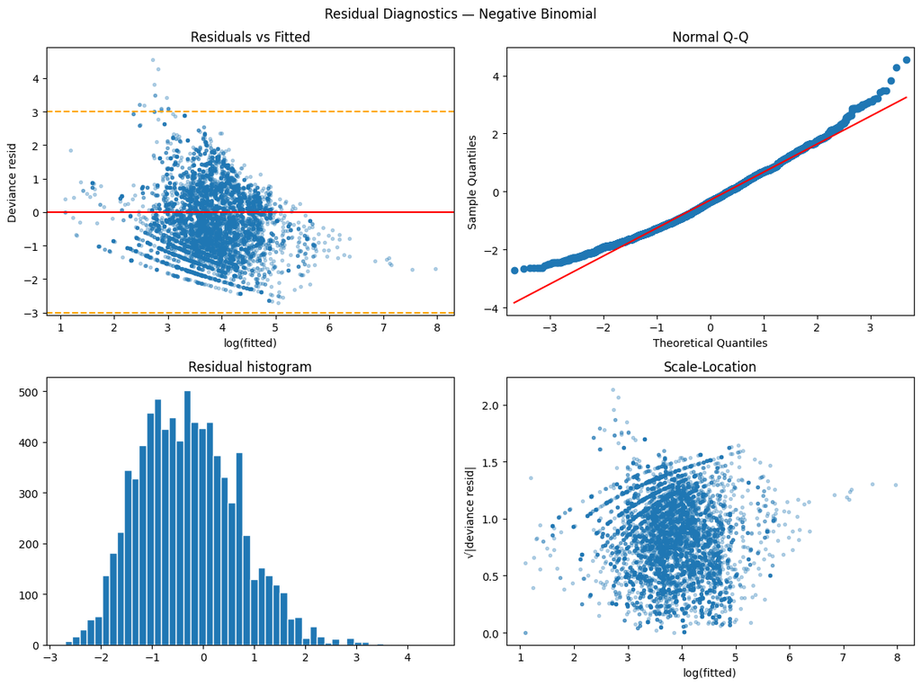

```python
# Residual Analysis plots
def residual_plots(model, df_fit, name=""):
    fig, axes = plt.subplots(2, 2, figsize=(12, 9))
    dev_r = model.resid_deviance
    fitted = model.fittedvalues

    # 1. Residuals vs fitted — check constant variance
    axes[0,0].scatter(np.log1p(fitted), dev_r, alpha=0.3, s=8)
    axes[0,0].axhline(0, color='r');
    axes[0,0].axhline(3, color='orange', ls='--')
    axes[0,0].axhline(-3, color='orange', ls='--')
    axes[0,0].set(xlabel='log(fitted)', ylabel='Deviance resid',
                  title='Residuals vs Fitted')

    # 2. QQ plot — check normality of residuals
    sm.qqplot(dev_r, line='s', ax=axes[0,1])
    axes[0,1].set_title('Normal Q-Q')

    # 3. Histogram of residuals
    axes[1,0].hist(dev_r, bins=50, edgecolor='white')
    axes[1,0].set_title('Residual histogram')

    # 4. Scale-location — check heteroscedasticity
    axes[1,1].scatter(np.log1p(fitted), np.sqrt(np.abs(dev_r)), alpha=0.3, s=8)
    axes[1,1].set(xlabel='log(fitted)', ylabel='√|deviance resid|',
                  title='Scale-Location')

    plt.suptitle(f'Residual Diagnostics — {name}')
    plt.tight_layout(); plt.show()

residual_plots(model1, fit_df, 'Negative Binomial')
```

Residuals vs fitted show mild heteroskedasticity and slight systematic structure, suggesting some remaining non-linearity or omitted heterogeneity despite the Negative Binomial choice. Q-Q and histogram indicate reasonable fit overall with mild tail deviations, so the model is acceptable but not fully capturing extreme district-level variation.

```python
model1.resid_pearson
```

```
0      -0.878853
1      -0.833354
2      -0.703202
3      -0.724055
4      -0.724055
          ...
8235   -0.903517
8236   -0.892601
8237   -0.529429
8238   -0.603808
8239   -0.828163
Length: 8234, dtype: float64
```

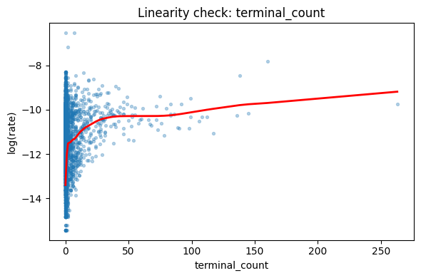

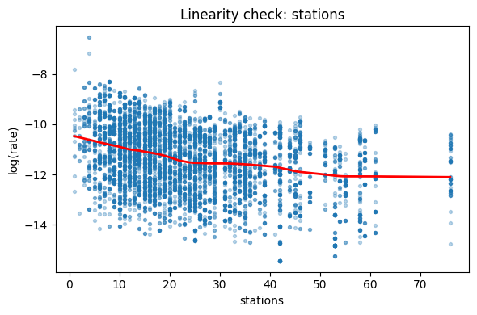

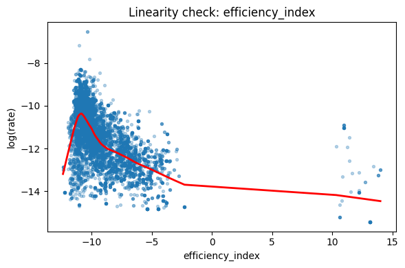

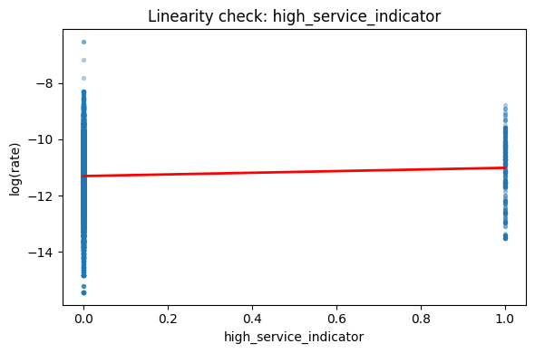

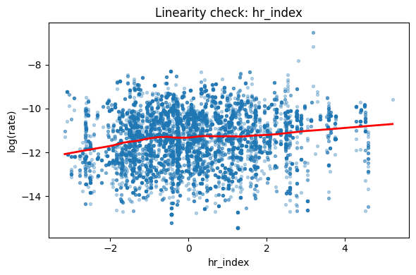

```python
#linearity assumption
for col in  ['terminal_count', 'stations', 'efficiency_index',
        'high_service_indicator', 'hr_index']:

    log_rate = np.log1p(fit_df['unique_trains']) - fit_df['offset']
    plt.figure(figsize=(6,4))
    plt.scatter(fit_df[col], log_rate, alpha=0.3, s=8)
    lowess = sm.nonparametric.lowess(log_rate, fit_df[col], frac=0.3)
    plt.plot(lowess[:,0], lowess[:,1], 'r-', lw=2)
    plt.xlabel(col); plt.ylabel('log(rate)')
    plt.title(f'Linearity check: {col}')
    plt.tight_layout(); plt.show()
```

Efficiency index doesn't hold the linearity assumption.Hence, we can square the term.

```python
models_spec = {
    'M1': 'unique_trains ~ terminal_count + stations + efficiency_index + high_service_indicator + hr_index',

    'M2': 'unique_trains ~ terminal_count + stations + efficiency_index + high_service_indicator + hr_index + worker_share + urban_rate + agri_share',

    'M3': 'unique_trains ~ terminal_count + stations + efficiency_index + high_service_indicator + hr_index + worker_share + urban_rate + agri_share + SVI_norm'
}
```

```python
#k-fold cv for negative binomial
from sklearn.model_selection import KFold
from sklearn.model_selection import StratifiedKFold
import statsmodels.formula.api as smf
from statsmodels.genmod import families
import numpy as np

def kfold_cv_nb(formula, df, offset_col, k=10, alpha=1.0):

    from sklearn.model_selection import StratifiedKFold

    kf = StratifiedKFold(n_splits=k, shuffle=True, random_state=42)

    mspe_list, pm_list, cim_list = [], [], []

    X = df.index.to_numpy()

    # better stratification than state
    y = pd.qcut(df["unique_trains"], q=5, labels=False)

    for train_i, test_i in kf.split(X, y):

        tr = df.iloc[train_i]
        te = df.iloc[test_i]

        model = smf.glm(
            formula,
            data=tr,
            family=families.NegativeBinomial(alpha=alpha),
            offset=tr[offset_col]
        ).fit(disp=False)

        pred = model.predict(te, offset=te[offset_col])
        obs = te["unique_trains"].values

        mspe = np.mean((pred - obs) ** 2)
        pm = mspe / np.var(obs)
        cim = np.mean(np.abs(pred - obs) / (obs + 1e-6))

        mspe_list.append(mspe)
        pm_list.append(pm)
        cim_list.append(cim)

    return {
        "MSPE": np.mean(mspe_list),
        "PM": np.mean(pm_list),
        "MAPE_proxy": np.mean(cim_list)
    }
```

```python
fit_df_clean = fit_df.reset_index(drop=True)
state_dummies = pd.get_dummies(fit_df_clean["State name"], drop_first=True)
fit_df_clean = pd.concat([fit_df_clean, state_dummies], axis=1)

cv_results = {}

for name, formula in models_spec.items():
    cv_results[name + "_NB"] = kfold_cv_nb(
        formula,
        fit_df_clean,
        'offset',
        alpha=1.0
    )
    print(f"{name}_NB:", cv_results[name + "_NB"])
```

```
M1_NB: {'MSPE': np.float64(11176.171988247179), 'PM': np.float64(4.188084281798447), 'MAPE_proxy': np.float64(3.110823007209132)}
M2_NB: {'MSPE': np.float64(9222.874214717793), 'PM': np.float64(3.4633818057592194), 'MAPE_proxy': np.float64(3.1408861661578613)}
M3_NB: {'MSPE': np.float64(8583.840878378225), 'PM': np.float64(3.22592361300129), 'MAPE_proxy': np.float64(3.1103672407586047)}
```

```python
#fitting model3_nb
from patsy import bs

formula = """
unique_trains ~ terminal_count + stations + efficiency_index + high_service_indicator + hr_index + worker_share + urban_rate + agri_share + SVI_norm
+ C(Q("State name"))
"""

finalmodel = smf.glm(
    formula,
    data=fit_df,
    family=families.NegativeBinomial(),
    offset=fit_df["offset"]
).fit(
    cov_type="cluster",
    cov_kwds={"groups": fit_df["District code"]}
)

print(finalmodel.summary())
```

```
                 Generalized Linear Model Regression Results
==============================================================================
Dep. Variable:          unique_trains   No. Observations:                 8234
Model:                            GLM   Df Residuals:                     8197
Model Family:        NegativeBinomial   Df Model:                           36
Link Function:                    Log   Scale:                          1.0000
Method:                          IRLS   Log-Likelihood:                -40381.
Date:                Mon, 27 Apr 2026   Deviance:                       9746.0
Time:                        08:08:35   Pearson chi2:                 1.23e+04
No. Iterations:                   100   Pseudo R-squ. (CS):             0.2126
Covariance Type:              cluster
===========================================================================================================
                                              coef    std err          z      P>|z|      [0.025      0.975]
-----------------------------------------------------------------------------------------------------------
Intercept                                 -11.8340      0.855    -13.839      0.000     -13.510     -10.158
C(Q("State name"))[T.ASSAM]                -0.0071      0.321     -0.022      0.982      -0.635       0.621
C(Q("State name"))[T.BIHAR]                -0.0211      0.275     -0.077      0.939      -0.560       0.518
C(Q("State name"))[T.CHANDIGARH]           -0.6041      0.334     -1.809      0.070      -1.259       0.051
C(Q("State name"))[T.CHHATTISGARH]         -0.3855      0.231     -1.669      0.095      -0.838       0.067
C(Q("State name"))[T.GOA]                   0.2373      0.250      0.949      0.343      -0.253       0.727
C(Q("State name"))[T.GUJARAT]              -0.4270      0.218     -1.956      0.050      -0.855       0.001
C(Q("State name"))[T.HARYANA]               0.1591      0.283      0.561      0.575      -0.396       0.714
C(Q("State name"))[T.HIMACHAL PRADESH]     -0.3964      0.328     -1.207      0.227      -1.040       0.247
C(Q("State name"))[T.JAMMU AND KASHMIR]     1.1868      0.496      2.392      0.017       0.214       2.159
C(Q("State name"))[T.JHARKHAND]             0.3486      0.261      1.334      0.182      -0.164       0.861
C(Q("State name"))[T.KARNATAKA]            -0.3875      0.211     -1.835      0.066      -0.801       0.026
C(Q("State name"))[T.KERALA]               -0.3572      0.269     -1.329      0.184      -0.884       0.169
C(Q("State name"))[T.MADHYA PRADESH]        0.4751      0.209      2.278      0.023       0.066       0.884
C(Q("State name"))[T.MAHARASHTRA]          -0.3910      0.185     -2.113      0.035      -0.754      -0.028
C(Q("State name"))[T.MANIPUR]              -2.6791      0.415     -6.452      0.000      -3.493      -1.865
C(Q("State name"))[T.MIZORAM]              -0.5992      0.370     -1.618      0.106      -1.325       0.127
C(Q("State name"))[T.NAGALAND]              0.7686      0.330      2.328      0.020       0.121       1.416
C(Q("State name"))[T.NCT OF DELHI]          0.4488      0.728      0.616      0.538      -0.978       1.876
C(Q("State name"))[T.ORISSA]                0.1179      0.228      0.516      0.606      -0.330       0.565
C(Q("State name"))[T.PONDICHERRY]          -1.1977      0.295     -4.061      0.000      -1.776      -0.620
C(Q("State name"))[T.PUNJAB]               -0.0591      0.288     -0.205      0.838      -0.624       0.506
C(Q("State name"))[T.RAJASTHAN]            -0.1428      0.263     -0.543      0.587      -0.659       0.373
C(Q("State name"))[T.TAMIL NADU]            0.5110      0.335      1.527      0.127      -0.145       1.167
C(Q("State name"))[T.TRIPURA]              -0.6631      0.441     -1.504      0.133      -1.527       0.201
C(Q("State name"))[T.UTTAR PRADESH]         0.1203      0.256      0.470      0.638      -0.381       0.622
C(Q("State name"))[T.UTTARAKHAND]          -0.1522      0.544     -0.280      0.780      -1.219       0.914
C(Q("State name"))[T.WEST BENGAL]          -0.1763      0.238     -0.741      0.459      -0.643       0.290
terminal_count                              0.0144      0.002      6.564      0.000       0.010       0.019
stations                                   -0.0218      0.004     -5.752      0.000      -0.029      -0.014
efficiency_index                           -0.0339      0.048     -0.708      0.479      -0.128       0.060
high_service_indicator                      0.2526      0.106      2.390      0.017       0.045       0.460
hr_index                                    0.2650      0.067      3.967      0.000       0.134       0.396
worker_share                                0.5258      1.131      0.465      0.642      -1.690       2.742
urban_rate                                  0.4060      0.338      1.201      0.230      -0.257       1.069
agri_share                                  0.7643      0.509      1.502      0.133      -0.233       1.762
SVI_norm                                    1.1633      0.618      1.883      0.060      -0.048       2.374
===========================================================================================================
```

```python
##individual co-efficients)   # coef, SE, z, p-value, 95% CI

# ── 6C. Rate ratios (exp of coefficients) ─────────────────────────────────
rr = pd.DataFrame({
    'coef': finalmodel.params,
    'rate_ratio': np.exp(finalmodel.params),
    'CI_low': np.exp(finalmodel.conf_int()[0]),
    'CI_high': np.exp(finalmodel.conf_int()[1]),
    'p_value': finalmodel.pvalues
})
rr
```

|  | coef | rate_ratio | CI_low | CI_high | p_value |
| --- | --- | --- | --- | --- | --- |
| Intercept | -11.834029 | 0.000007 | 0.000001 | 0.000039 | 1.490824e-43 |
| C(Q("State name"))[T.ASSAM] | -0.007099 | 0.992926 | 0.529720 | 1.861178 | 9.823329e-01 |
| C(Q("State name"))[T.BIHAR] | -0.021133 | 0.979089 | 0.571268 | 1.678049 | 9.387195e-01 |
| C(Q("State name"))[T.CHANDIGARH] | -0.604082 | 0.546576 | 0.284032 | 1.051799 | 7.048994e-02 |
| C(Q("State name"))[T.CHHATTISGARH] | -0.385471 | 0.680130 | 0.432561 | 1.069392 | 9.503659e-02 |
| C(Q("State name"))[T.GOA] | 0.237315 | 1.267840 | 0.776662 | 2.069651 | 3.425612e-01 |
| C(Q("State name"))[T.GUJARAT] | -0.426992 | 0.652469 | 0.425379 | 1.000792 | 5.042537e-02 |
| C(Q("State name"))[T.HARYANA] | 0.159063 | 1.172412 | 0.672755 | 2.043164 | 5.746043e-01 |
| C(Q("State name"))[T.HIMACHAL PRADESH] | -0.396390 | 0.672744 | 0.353473 | 1.280394 | 2.273509e-01 |
| C(Q("State name"))[T.JAMMU AND KASHMIR] | 1.186822 | 3.276653 | 1.238960 | 8.665699 | 1.676673e-02 |
| C(Q("State name"))[T.JHARKHAND] | 0.348581 | 1.417055 | 0.848958 | 2.365306 | 1.823561e-01 |
| C(Q("State name"))[T.KARNATAKA] | -0.387505 | 0.678748 | 0.448716 | 1.026705 | 6.648274e-02 |
| C(Q("State name"))[T.KERALA] | -0.357228 | 0.699613 | 0.413181 | 1.184609 | 1.836921e-01 |
| C(Q("State name"))[T.MADHYA PRADESH] | 0.475111 | 1.608193 | 1.068543 | 2.420384 | 2.273812e-02 |
| C(Q("State name"))[T.MAHARASHTRA] | -0.390961 | 0.676407 | 0.470626 | 0.972164 | 3.464332e-02 |
| C(Q("State name"))[T.MANIPUR] | -2.679109 | 0.068624 | 0.030412 | 0.154847 | 1.100654e-10 |
| C(Q("State name"))[T.MIZORAM] | -0.599248 | 0.549224 | 0.265734 | 1.135150 | 1.057171e-01 |
| C(Q("State name"))[T.NAGALAND] | 0.768554 | 2.156645 | 1.129152 | 4.119122 | 1.991866e-02 |
| C(Q("State name"))[T.NCT OF DELHI] | 0.448833 | 1.566483 | 0.375888 | 6.528199 | 5.376722e-01 |
| C(Q("State name"))[T.ORISSA] | 0.117861 | 1.125088 | 0.719282 | 1.759843 | 6.055970e-01 |
| C(Q("State name"))[T.PONDICHERRY] | -1.197658 | 0.301900 | 0.169358 | 0.538172 | 4.894374e-05 |
| C(Q("State name"))[T.PUNJAB] | -0.059078 | 0.942634 | 0.535788 | 1.658414 | 8.376035e-01 |
| C(Q("State name"))[T.RAJASTHAN] | -0.142847 | 0.866887 | 0.517515 | 1.452116 | 5.873191e-01 |
| C(Q("State name"))[T.TAMIL NADU] | 0.511047 | 1.667035 | 0.865249 | 3.211800 | 1.266665e-01 |
| C(Q("State name"))[T.TRIPURA] | -0.663090 | 0.515257 | 0.217173 | 1.222481 | 1.325166e-01 |
| C(Q("State name"))[T.UTTAR PRADESH] | 0.120282 | 1.127815 | 0.682902 | 1.862589 | 6.384174e-01 |
| C(Q("State name"))[T.UTTARAKHAND] | -0.152166 | 0.858845 | 0.295658 | 2.494829 | 7.797275e-01 |
| C(Q("State name"))[T.WEST BENGAL] | -0.176293 | 0.838373 | 0.525775 | 1.336826 | 4.589747e-01 |
| terminal_count | 0.014418 | 1.014523 | 1.010164 | 1.018900 | 5.234916e-11 |
| stations | -0.021845 | 0.978392 | 0.971137 | 0.985702 | 8.801700e-09 |
| efficiency_index | -0.033867 | 0.966700 | 0.880177 | 1.061728 | 4.789899e-01 |
| high_service_indicator | 0.252604 | 1.287374 | 1.046513 | 1.583670 | 1.684166e-02 |
| hr_index | 0.265010 | 1.303444 | 1.143494 | 1.485768 | 7.267867e-05 |
| worker_share | 0.525767 | 1.691756 | 0.184515 | 15.511167 | 6.418859e-01 |
| urban_rate | 0.406010 | 1.500818 | 0.773601 | 2.911650 | 2.298383e-01 |
| agri_share | 0.764339 | 2.147575 | 0.792288 | 5.821212 | 1.330120e-01 |
| SVI_norm | 1.163266 | 3.200370 | 0.953285 | 10.744283 | 5.976248e-02 |

##### Model3(Rail + Development+ Demand + Need): equity-adjusted accessibility

log(λi)=β0+β1Terminali+β2Efficiencyi+β3stationsi+β4high_service_indicatori+β5WorkerSharei+β6UrbanRatei+β7AgriSharei+β8HRIndexi+β9SVIi++β10Statenamei+log(Pop)

```python
#predict unique trains for the model
rail_df['pred_rail'] = finalmodel.predict(
    rail_df)


#calculate the observed/predicted and convert it RAS (0 TO 1)
rail_df['ras_ratio'] = rail_df['unique_trains'] / rail_df['pred_rail']
rail_df['ras_log'] = np.log(rail_df['unique_trains'] / rail_df['pred_rail'])
rail_df['ras_0_1'] = rail_df['ras_log'].rank(pct=True)


rail_df = rail_df.merge(
    rail_df[['pred_rail']],
    left_index=True,
    right_index=True,
    how='left')
```

```python
rail_df[['geometry', 'ras_ratio', 'ras_log', 'ras_0_1']].describe()#df.groupby('District_name')['ras_0_1'].mean()[['ras_ratio', 'ras_log', 'ras_0_1']].describe()#df.groupby('District_name')['ras_0_1'].mean()
```

|  | ras_ratio | ras_log | ras_0_1 |
| --- | --- | --- | --- |
| count | 8.234000e+03 | 8234.000000 | 8234.000000 |
| mean | 2.962439e+06 | 14.218711 | 0.500061 |
| std | 3.716841e+06 | 1.278372 | 0.288693 |
| min | 1.647302e+04 | 9.709479 | 0.000121 |
| 25% | 6.056041e+05 | 13.313982 | 0.250000 |
| 50% | 1.706267e+06 | 14.349818 | 0.500091 |
| 75% | 3.987304e+06 | 15.198626 | 0.750030 |
| max | 5.146031e+07 | 17.756321 | 0.999939 |

```python
rail_df[['geometry', 'ras_ratio', 'ras_log', 'ras_0_1']]
```

|  | geometry | ras_ratio | ras_log | ras_0_1 |
| --- | --- | --- | --- | --- |
| 0 | MULTIPOLYGON (((77.5911 8.1418, 77.58991 8.145... | 183732.963146 | 12.121239 | 0.060359 |
| 1 | MULTIPOLYGON (((77.5911 8.1418, 77.58991 8.145... | 252316.903663 | 12.438441 | 0.099830 |
| 2 | MULTIPOLYGON (((77.5911 8.1418, 77.58991 8.145... | 438681.920204 | 12.991530 | 0.184600 |
| 3 | MULTIPOLYGON (((77.5911 8.1418, 77.58991 8.145... | 415401.447025 | 12.937001 | 0.175674 |
| 4 | MULTIPOLYGON (((77.5911 8.1418, 77.58991 8.145... | 415401.447025 | 12.937001 | 0.175674 |
| ... | ... | ... | ... | ... |
| 8235 | MULTIPOLYGON (((74.94665 32.87708, 74.93383 32... | 112660.230824 | 11.632132 | 0.026840 |
| 8236 | MULTIPOLYGON (((74.94665 32.87708, 74.93383 32... | 128804.431495 | 11.766050 | 0.032001 |
| 8237 | MULTIPOLYGON (((75.29152 33.09688, 75.26395 33... | 240603.378120 | 12.390905 | 0.093879 |
| 8238 | MULTIPOLYGON (((75.29152 33.09688, 75.26395 33... | 202376.603140 | 12.217886 | 0.072626 |
| 8239 | MULTIPOLYGON (((75.07635 33.1643, 75.06955 33.... | 48554.528206 | 10.790443 | 0.005951 |

8234 rows × 4 columns

```python
#MERGE IT WITH THE GEOCODES TO MAP IT TO DISTRICT LEVEL
import geopandas as gpd

districts = gpd.read_file('districts.json')
districts.columns
```

```
Index(['DISTRICT', 'ST_NM', 'ST_CEN_CD', 'DT_CEN_CD', 'censuscode',
       'geometry'],
      dtype='str')
```

```python
gdf=rail_df
```

```python
joined = gpd.sjoin(
    gdf[['geometry', 'ras_0_1','SVI_norm']],
    districts,
    how='inner',
    predicate='intersects'
)
#Aggregate RAS scores at the district level
district_values = (
    joined
    .groupby(['DISTRICT', 'ST_NM'])['ras_0_1']
    .mean()   # or sum / median depending on meaning
    .reset_index()
)
merged = districts.merge(
    district_values,
    on=['DISTRICT', 'ST_NM'],
    how='left'
)
```

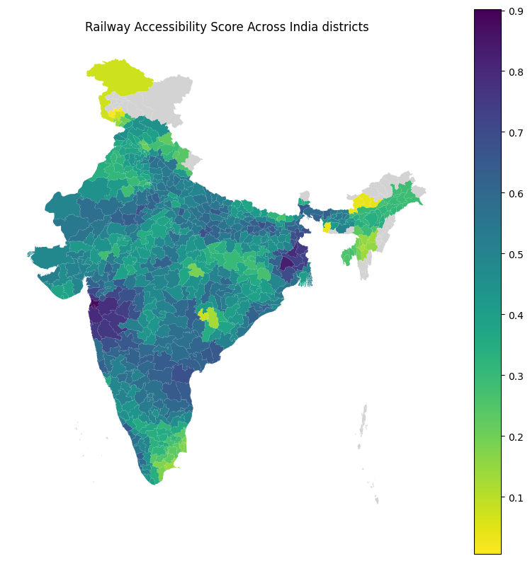

```python
import matplotlib.pyplot as plt

fig, ax = plt.subplots(1, 1, figsize=(10, 10))

merged.plot(
    column='ras_0_1',
    cmap='viridis_r',
    legend=True,
    ax=ax,
    edgecolor='none',
    missing_kwds={"color": "lightgrey"}
)

ax.set_title("Railway Accessibility Score Across India districts")
ax.axis('off')

plt.show()
```

```python
joined = gpd.sjoin(
    gdf[['geometry', 'ras_0_1','SVI_norm']],
    districts,
    how='inner',
    predicate='intersects'
)
district_values = (
    joined
    .groupby(['DISTRICT', 'ST_NM'])['SVI_norm']
    .mean()   # or sum / median depending on meaning
    .reset_index()
)
merged = districts.merge(
    district_values,
    on=['DISTRICT', 'ST_NM'],
    how='left'
)
```

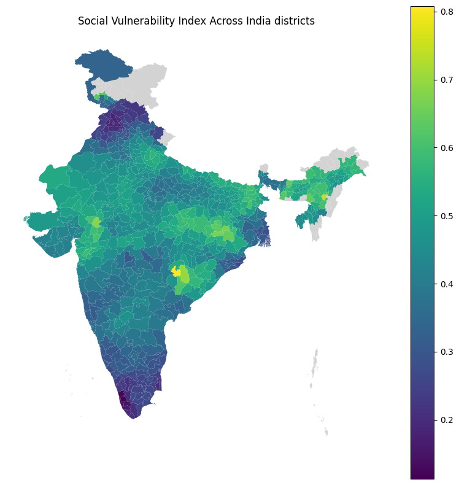

```python
import matplotlib.pyplot as plt

fig, ax = plt.subplots(1, 1, figsize=(10, 10))

merged.plot(
    column='SVI_norm',
    cmap='viridis',
    legend=True,
    ax=ax,
    edgecolor='none',
    missing_kwds={"color": "lightgrey"}
)

ax.set_title("Social Vulnerability Index Across India districts")
ax.axis('off')

plt.show()
```

Reversed the colours since high SVI index is not preferred, like low RAS.

```python
#Relation between Social Vulnerability Index and RAS
x_med = rail_df['SVI_norm'].median()
y_med = rail_df['ras_0_1'].median()
#quadrant labels
def get_quadrant(row):
    if row['SVI_norm'] >= x_med and row['ras_0_1'] >= y_med:
        return "High Need - High Access (Balanced)"
    elif row['SVI_norm'] >= x_med and row['ras_0_1'] < y_med:
        return "High Need - Low Access (Underserved)"
    elif row['SVI_norm'] < x_med and row['ras_0_1'] >= y_med:
        return "Low Need - High Access (Over-served)"
    else:
        return "Low Need - Low Access (Structurally weak)"
rail_df['quadrant'] = rail_df.apply(get_quadrant, axis=1)
```

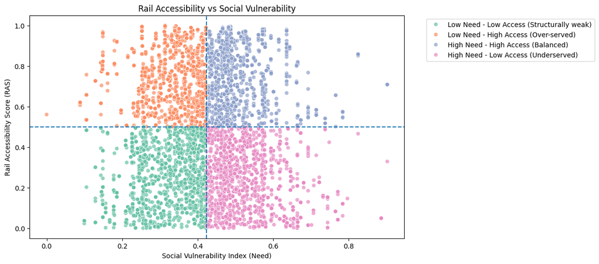

```python
import seaborn as sns
import matplotlib.pyplot as plt

plt.figure(figsize=(10,6))

sns.scatterplot(
    data=rail_df,
    x='SVI_norm',
    y='ras_0_1',
    hue='quadrant',
    palette='Set2',
    alpha=0.7
)

plt.axvline(x_med, linestyle='--')
plt.axhline(y_med, linestyle='--')

plt.title("Rail Accessibility vs Social Vulnerability")
plt.xlabel("Social Vulnerability Index (Need)")
plt.ylabel("Rail Accessibility Score (RAS)")
plt.legend(bbox_to_anchor=(1.05, 1))
plt.show()
```

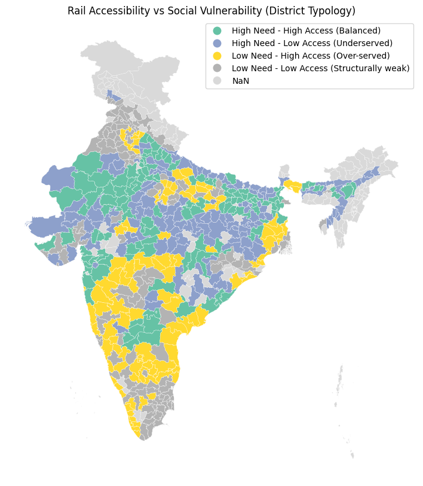

```python
joined = gpd.sjoin(
    rail_df,
    districts[['DISTRICT', 'ST_NM', 'geometry']],
    how='inner',
    predicate='within'
)
district_quadrant = (
    joined.groupby(['DISTRICT', 'ST_NM'])['quadrant']
    .agg(lambda x: x.value_counts().idxmax())
    .reset_index()
)
district_map = districts.merge(
    district_quadrant,
    on=['DISTRICT', 'ST_NM'],
    how='left'
)
import matplotlib.pyplot as plt

fig, ax = plt.subplots(1, 1, figsize=(10, 10))

district_map.plot(
    column='quadrant',
    categorical=True,
    legend=True,
    cmap='Set2',
    ax=ax,
    missing_kwds={"color": "#d9d9d9"},
    edgecolor='white',
    linewidth=0.2
)

ax.set_title("Rail Accessibility vs Social Vulnerability (District Typology)")
ax.axis('off')

plt.show()
```